# Intro to Bayesian Analysis

Rob Cribbie

22-01-2025

Open the Dataset - Online Intervention

```r
library(negligible)
dat <- perfectionism
names(dat)
```

```
##  [1] "group"          "mpshfpre.sop"   "mpshfpre.spp"   "pcipre.total"
##  [5] "baipre.total"   "cesdpre.total"  "mpsfpre.cm"     "mpshfpost.sop"
##  [9] "mpshfpost.spp"  "pcipost.total"  "baipost.total"  "cesdpost.total"
## [13] "mpsfpost.cm"    "atqpre.total"   "atqpost.total"  "mpshfpre.oop"
## [17] "mpshfpost.oop"
```

We will be using a couple pretest variables for our simple regression analysis:

mpsfpre.cm = concern over mistakes

cesdpre = depression

### Correlation/Plot of the relationship between mpsfpre.cm and cesdpre

```r
cor(dat$cesdpre.total,dat$mpsfpre.cm)
```

```
## [1] 0.4026916
```

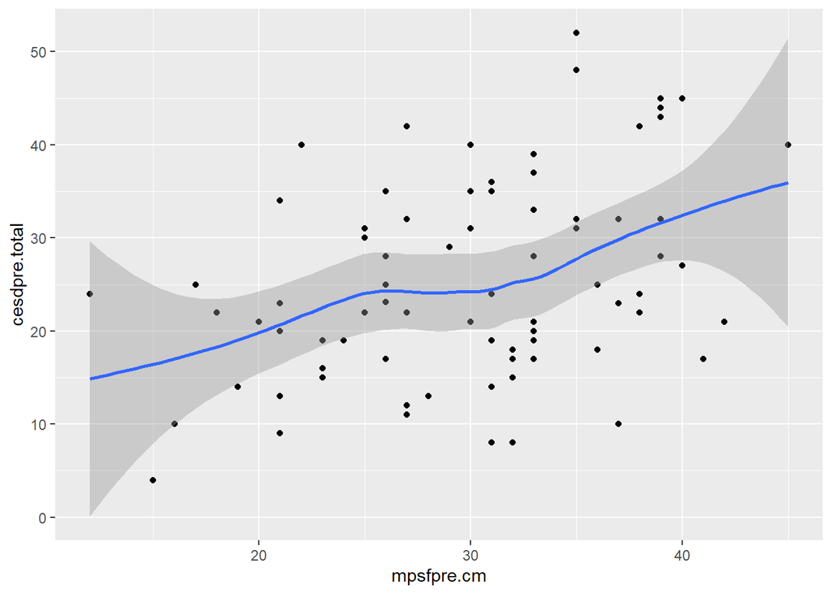

```r
library(ggplot2)
ggplot(dat,aes(x=mpsfpre.cm, y=cesdpre.total)) +
  geom_point() + geom_smooth()
```

### Traditional regression model, including a null hypothesis significance test (NHST) and a confidence interval for the mpsfpre.com parameter.

```r
m<-lm(cesdpre.total ~ mpsfpre.cm, data=dat)
summary(m)
```

```
##
## Call:
## lm(formula = cesdpre.total ~ mpsfpre.cm, data = dat)
##
## Residuals:
##     Min      1Q  Median      3Q     Max
## -19.727  -7.058  -1.664   8.442  23.485
##
## Coefficients:
##             Estimate Std. Error t value Pr(>|t|)
## (Intercept)   7.2935     4.7217   1.545 0.126320
## mpsfpre.cm    0.6063     0.1531   3.959 0.000161 ***
## ---
## Signif. codes:  0 '***' 0.001 '**' 0.01 '*' 0.05 '.' 0.1 ' ' 1
##
## Residual standard error: 9.936 on 81 degrees of freedom
## Multiple R-squared:  0.1622, Adjusted R-squared:  0.1518
## F-statistic: 15.68 on 1 and 81 DF,  p-value: 0.0001605
```

```r
confint(m)
```

```
##                  2.5 %     97.5 %
## (Intercept) -2.1011402 16.6881038
## mpsfpre.cm   0.3016348  0.9110066
```

A one unit increase in ‘Concern over Mistakes’ leads to a .6 unit increase in depression, which is statistically significant. The CI is moderately narrow. Don’t forget the limitations of these frequentist interpretations.

### Bayesian regression using the default priors.

```r
library(rstanarm)
mb<-stan_glm(cesdpre.total ~ mpsfpre.cm,
              data=dat, refresh=0)
```

### Distribution of the posterior for the predictor ‘Concern over Mistakes’.

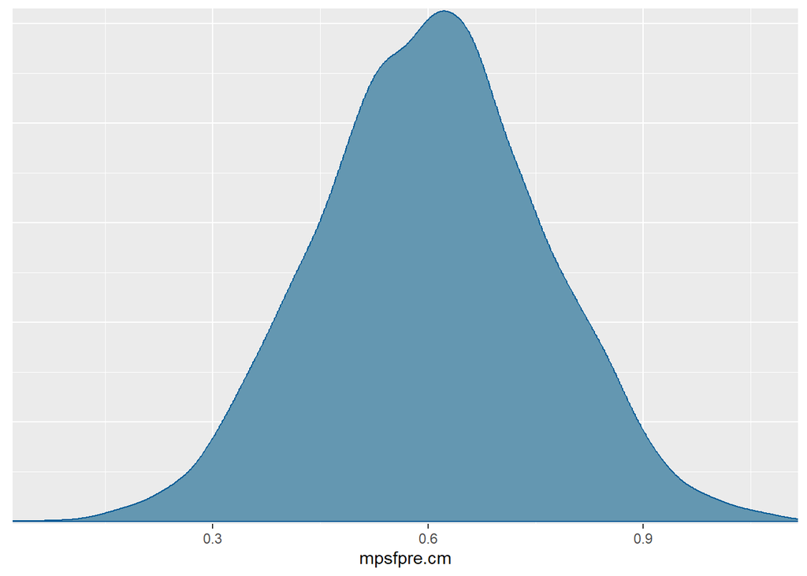

```r
library(bayesplot)
mcmc_dens(mb,pars=c("mpsfpre.cm"))
```

### 95% credible interval for the ‘Concern over Mistakes’ parameter

```r
library(bayestestR)
# Highest Density Interval
hdi(mb)
```

```
## Highest Density Interval
##
## Parameter   |        95% HDI
## ----------------------------
## (Intercept) | [-2.10, 16.88]
## mpsfpre.cm  | [ 0.29,  0.90]
```

There is a 95% chance that the ‘Concern over Mistakes’ parameter falls between around .3 and .9.

### Change the prior (very aggressively): Reduce the SD of the prior for the ‘Concern over Mistakes’ parameter to .1. Is there any effect on the parameter or its credible interval?

```r
m1b<-stan_glm(cesdpre.total ~ mpsfpre.cm, prior = normal(0, .1, autoscale = FALSE), data=dat, refresh=0)
coef(m1b)
```

```
## (Intercept)  mpsfpre.cm
##  20.3477919   0.1685818
```

```r
coef(mb)
```

```
## (Intercept)  mpsfpre.cm
##    7.415042    0.603549
```

```r
hdi(m1b)
```

```
## Highest Density Interval
##
## Parameter   |        95% HDI
## ----------------------------
## (Intercept) | [15.21, 26.06]
## mpsfpre.cm  | [ 0.00,  0.33]
```

```r
hdi(mb)
```

```
## Highest Density Interval
##
## Parameter   |        95% HDI
## ----------------------------
## (Intercept) | [-2.10, 16.88]
## mpsfpre.cm  | [ 0.29,  0.90]
```

Given the relatively small N (N = 83) and VERY informative prior (sd = .1), the parameter is reduced substantially and with a much narrower CI.